# Final Project

Estephani Barroso, Kassandra Chino Gonzalez, Yu-Fang Huang

2023-11-07

## Team members:

Estephani Barroso, Kassandra Chino Gonzalez, Yu-Fang Huang

## Date set:

COVID-19 Daily Counts of Cases

# url:

https://data.cityofnewyork.us/api/views/rc75-m7u3/rows.csv?accessType=DOWNLOAD

## Introduction and Research Questions:

COVID-19 has been a global health crisis since late 2019, and here we would like to focus on COVID-19 cases and deaths in the five regions in New York City. We will address several questions and give a conclusion of what causes the increase in cases and deaths.

- Which of the five regions has the highest death in COVID-19? We will analyze which of the five regions has the highest death in COVID-19 and maybe give assumption or inference of why this region has the highest death.
- On which day has the most COVID-19 cases? We will explore and find out which day has the most covid-19 cases.
- Which month in each year had the most cases in NYC? Most deaths? We will give numeric values showing which month in each year has the most cases and deaths in NYC and explain why it has the most cases and deaths.
- What is the average number of deaths and COVID-19 cases on a yearly, monthly basis in NYC? We will calculate the average number of deaths and cases for each year and each month and see if there are any increases or decreases due to the vaccines.
- Visualization of NYC COVID-19 cases and deaths breakdown by year, month, day, and weekday. We will create plots to easily compare which month and year has the highest or lowest cases and deaths.

## Description of your data set:

This data set counts the daily number of people in New York City who tested positive for COVID-19, were hospitalized with COVID-19, and the number of deaths among COVID-19 patients. This data set includes 67 variables and 1158 observations. These observations are recorded from 2/29/2020 to 5/1/2023. All of the variables are integer values. For the first few columns, it counts the daily number of cases and deaths in New York City, then counts the average seven days of those records. After that, it broke down into five different regions, which are Brooklyn (BK), Bronx (BX), Manhattan (MN), Queens (QU), and Staten Island (SI). Each region also counts the total cases and deaths and the average seven days of those cases.

```r
library(readr)
library(tidyverse)
```

## Methods

We mostly used the tydiverse package for our data exploration to get our results. For example, we used lubridate to change the format of the date, we also used ggplot2 to do our visualization for our research questions.

# Overview

```
##   TotalDays TotalDeaths TotalCases  DeathRate
## 1      1158       38777    2731350 0.01419701
```

```
## # A tibble: 4 × 4
##    Year TotalValue TotalCases    Rate
##   <dbl>      <int>      <int>   <dbl>
## 1  2020      20324     401563 0.0506
## 2  2021       9867    1058347 0.00932
## 3  2022       7454    1173786 0.00635
## 4  2023       1132      97654 0.0116
```

```
## # A tibble: 12 × 4
##    Month TotalValue TotalCases    Rate
##    <ord>      <int>      <int>   <dbl>
##  1 Jan         5695     656583 0.00867
##  2 Feb         3399     135817 0.0250
##  3 Mar         4325     194839 0.0222
##  4 Apr        14104     228743 0.0617
##  5 May         3588     144137 0.0249
##  6 Jun         1151      96841 0.0119
##  7 Jul          725     131002 0.00553
##  8 Aug          823     120826 0.00681
##  9 Sep          787      97582 0.00807
## 10 Oct          817      92239 0.00886
## 11 Nov         1006     143986 0.00699
## 12 Dec         2357     688755 0.00342
```

# Graphical Display of Deaths and Cases of COVID-19 Per Year

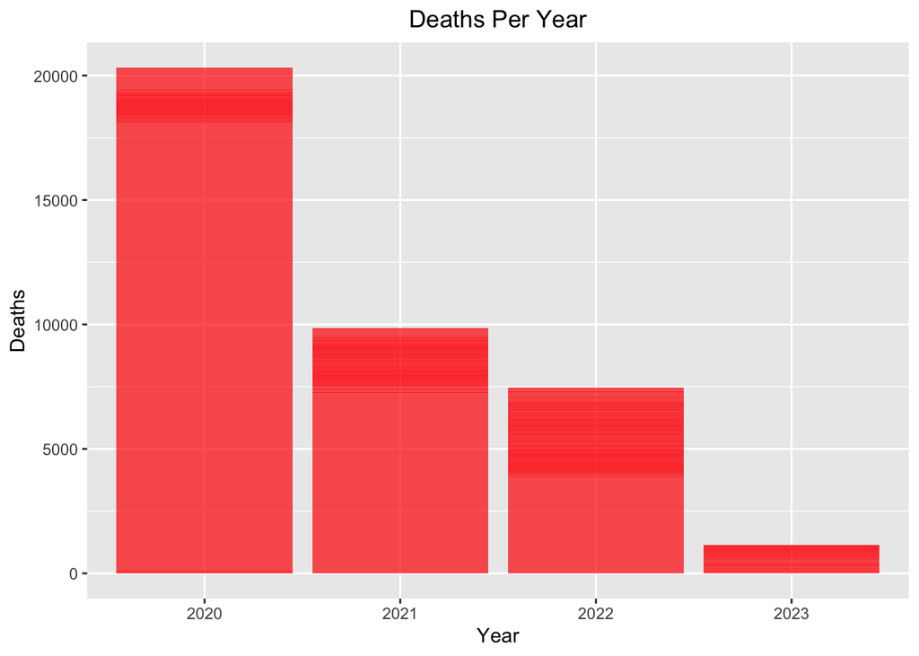

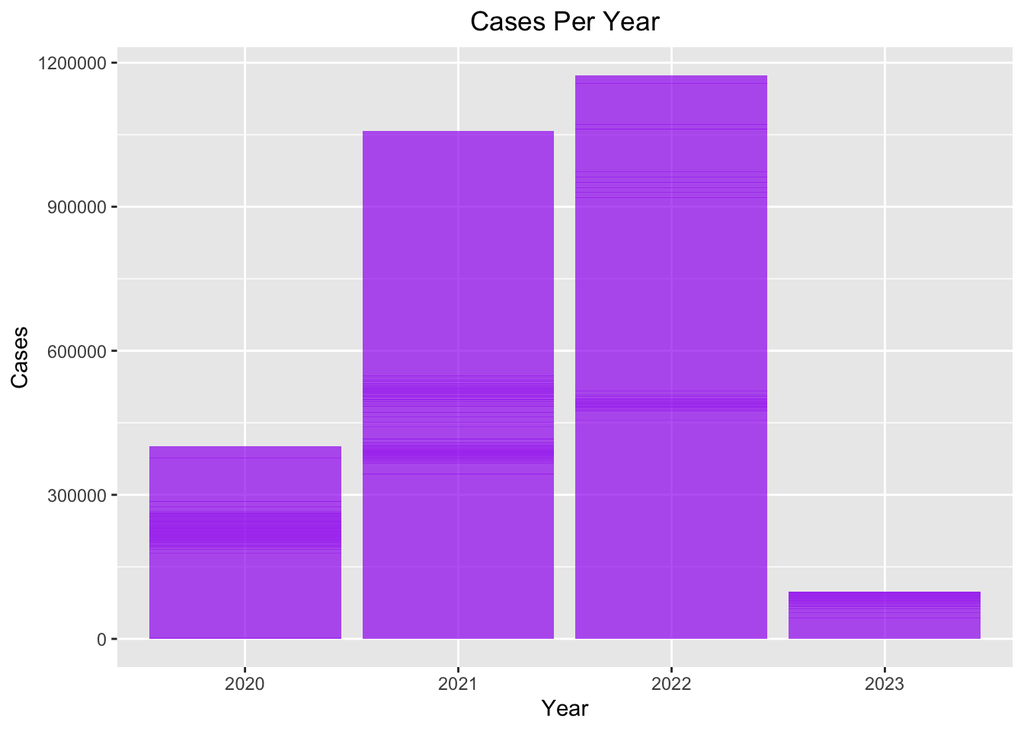

We wanted to explore the difference in cases and deaths between each year to see if there were any patterns. In the graphs above we can see there are definitely patterns. First of all, we can see that the amount of deaths starts really high in 2020, but the amount starts to decrease each year. On the other hand, we can see how the amount of cases start to increase. The year 2023, has less data that we can look at, so we tried not to compare it a lot with the over years. As for the patterns, we think that the reason there were more deaths at the beginning is due to the fact that we were all unfamiliar with the effects of COVID-19 and how we were supposed to take care. On the other hand, the reason for the increase of cases has to to the fact that the virus was spreading across all the world.

# Graphical Display of Total Deaths and Total Cases of COVID-19 Per Month

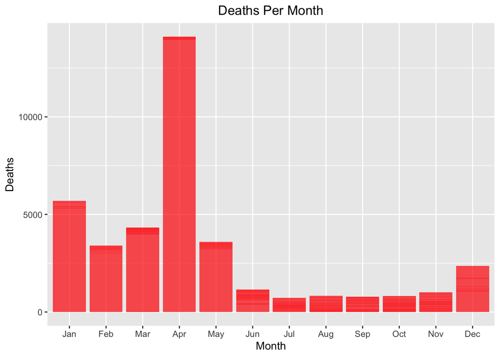

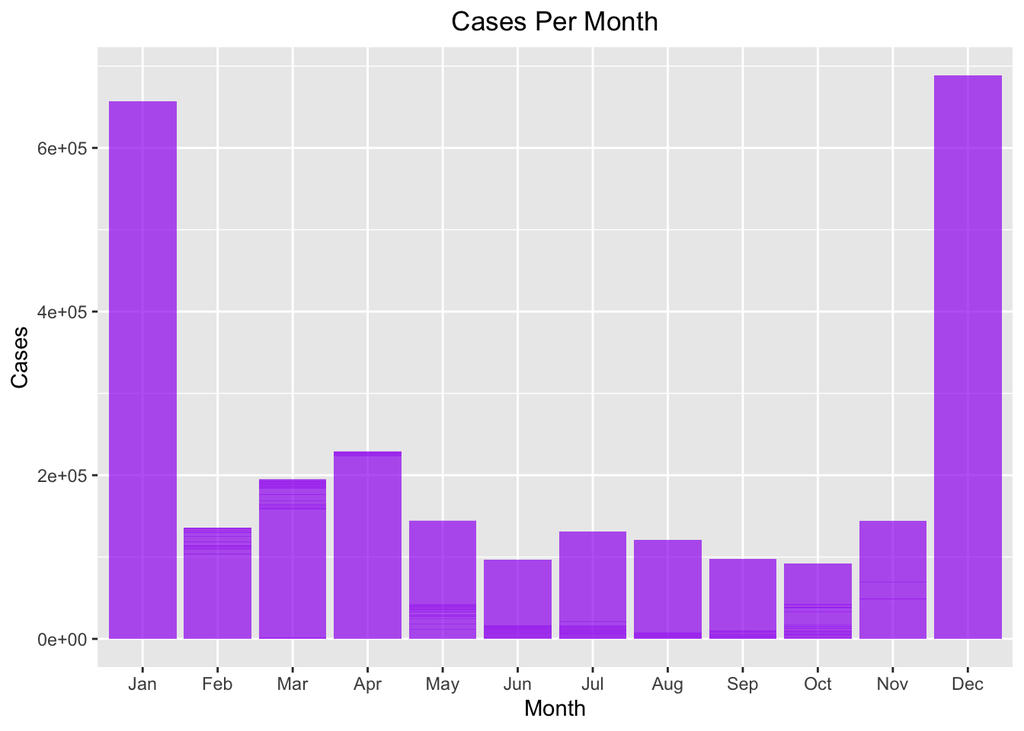

We were also interested at looking at the differences between total deaths and cases in each month. One pattern we noticed was that both the amount of cases and the amount of deaths were higher towards the first and last months when being compared to the months in between. We also noticed that the amount of deaths in April had a really a really high amount of deaths. So, we decided that there needed to be more investigation as to why there are more cases and deaths towards the first and last months and why there are way more deaths in April.

# Graphical Display of Deaths and Cases of COVID-19 Per Month and Year

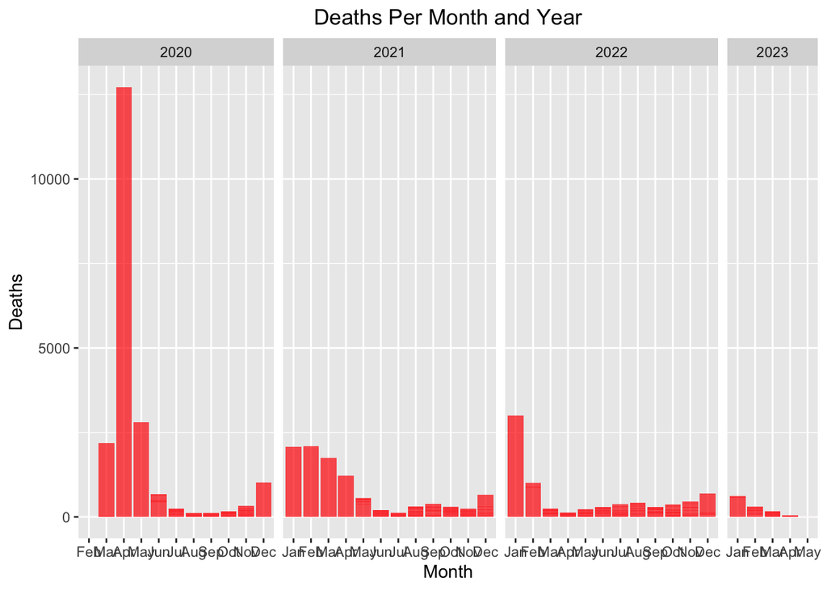

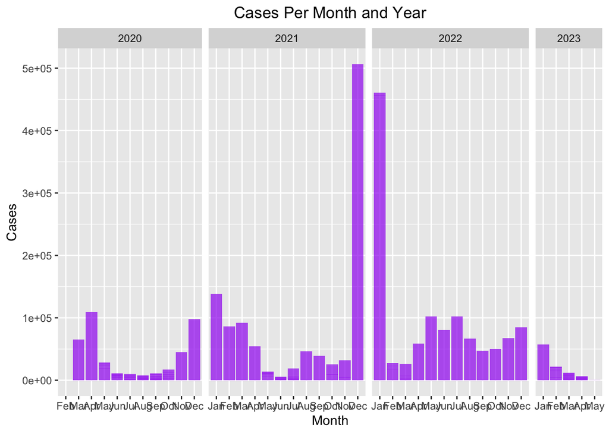

We looked at the differences in deaths and cases based on year and month to investigate the patterns we found on the previous graphs. We can see from the bar graph for total cases per month that there was a spike in cases during December 2021 and January 2022. The reason behind this has to do to people starting to lose fear of getting infected. They started to celebrate the holidays. Due to New York being a popular tourist attraction for the holidays, more people visited and got together to celebrate. Also, we noticed that there is a pattern in cases and deaths in which the beginning and end of each year have more cases than in between. This also has to do to people celebrating the holidays. Lastly, we can see that there is a spike in April 2020, which has to do with the fact that it was when COVID started to spread. We were not prepared to know how it would affect us and how we needed to get protected, which made the affects worse.

# Which month in each year had the most cases in NYC? Most deaths?

```
## # A tibble: 4 × 3
## # Groups:   Year [4]
##   Month  Year TotalCases
##   <ord> <dbl>      <int>
## 1 Apr    2020     109296
## 2 Dec    2021     506398
## 3 Jan    2022     460364
## 4 Jan    2023      57597
```

```
## # A tibble: 4 × 3
## # Groups:   Year [4]
##   Month  Year TotalDeaths
##   <ord> <dbl>       <int>
## 1 Apr    2020       12716
## 2 Feb    2021        2093
## 3 Jan    2022        3001
## 4 Jan    2023         626
```

We explored data on the months with the highest number of COVID-19 cases from 2020 to 2023. In 2020, April had the most cases with a total of 109,296. This can be attributed to the early stages of the pandemic when testing sites were being established nationwide. The month with the highest number of cases in 2021 was December, with a total of 506,398. For 2022, January had 460,364 cases, and January 2023 had 57,597 cases. It’s evident that the months with the most cases are either early or late in the year.

We have analyzed data on the month in each of the years 2020, 2021, 2022, and 2023, that had the highest number of deaths. In April 2020, the month with the most cases, there were 12,716 deaths. February 2021 had a total of 2,093 deaths, while January 2022 saw 3,001 deaths. Finally, January 2023 had a total of 626 deaths. It is clear from this data that the months with the highest number of deaths are in the early part of the year. As a result of COVID containment measures, vaccine development, and research, there was a significant decrease in the number of COVID cases and deaths in January 2023 compared to April 2020

# Graphical Display of Deaths and Cases of COVID-19 Per Day

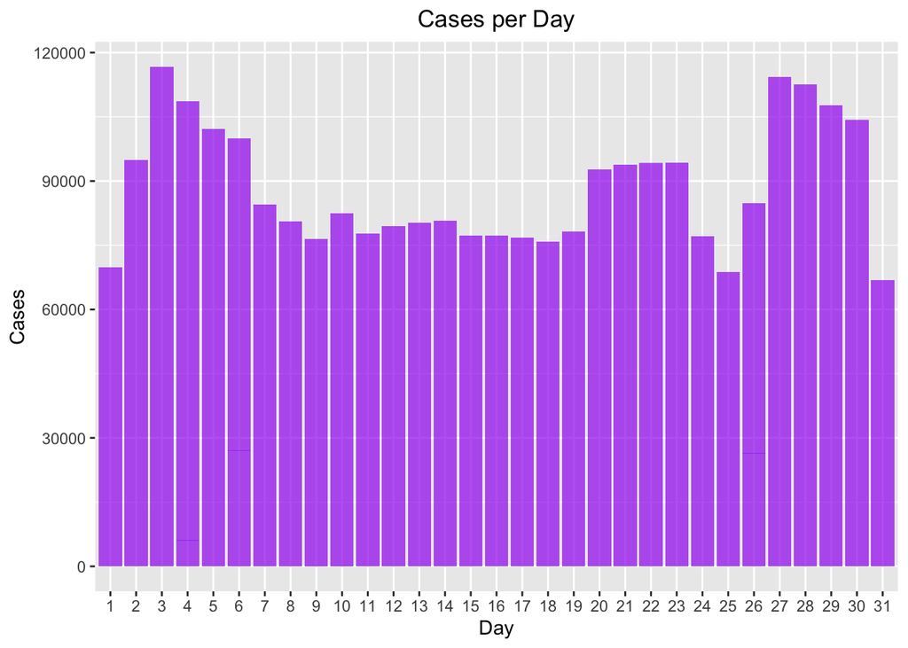

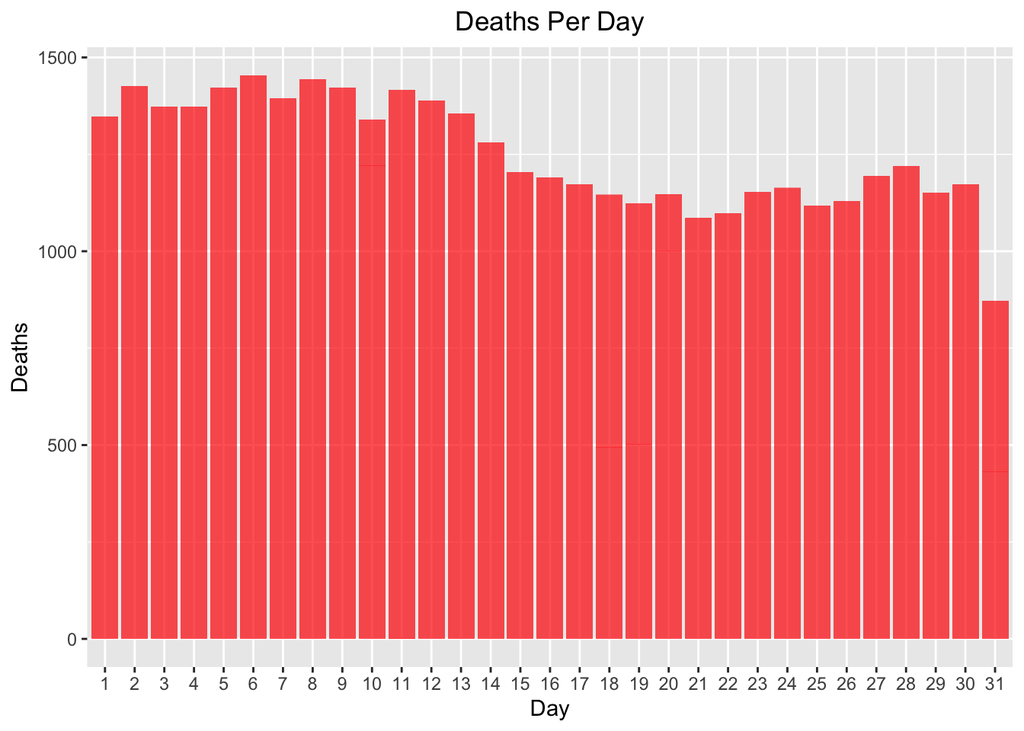

We also wanted to see if there was a pattern in the amount of cases and deaths based on the day of the month. We did noticed that there was a pattern in the total cases. There seems to be a higher amount of cases towards the first and last days of the months. This has to do to the fact that we mentioned before, that people started to get together for the holidays, which are at the end of December and beginning January. As for the deaths, there is not a huge difference based on the day.

# Graphical Display of Deaths and Cases of COVID-19 Per Weekday

```
## # A tibble: 7 × 2
##   weekdays  Days
##   <ord>    <int>
## 1 Sun        166
## 2 Mon        166
## 3 Tue        165
## 4 Wed        165
## 5 Thu        165
## 6 Fri        165
## 7 Sat        166
```

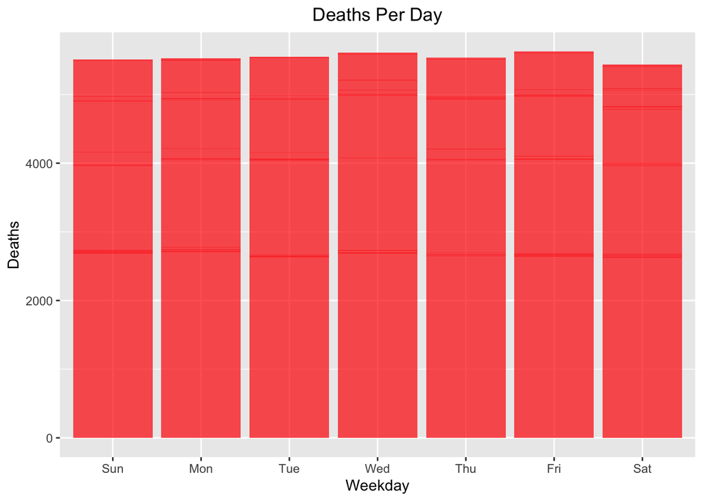

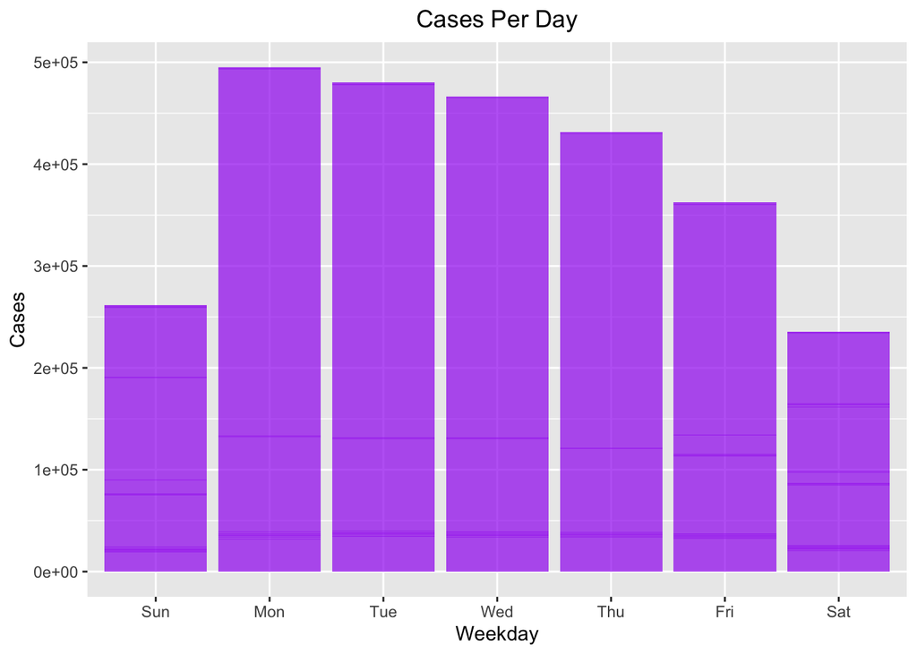

We also wanted to see if there was a pattern in cases and deaths based on the weekday. First, we looked at the amount of days for each weekday, and we noticed that each day had either 165 or 166 days, which means that we do not have to worry about the difference in the number of observations for each weekday. Based on the graph for deaths, we noticed there was no big difference in the amount of deaths for each weekday. As for the amount of deaths, we did notice some patters. One pattern was that during the weekend there were less cases, which has to do with many clinics being closed, so less people were being tested. A second pattern was that there was more cases towards the beginning of the week, which again has to do with clinics being closed. People who start feeling sick during the weekend make their appointment to get tested as the week started.

# Graphical Display of Average Deaths and Cases of COVID-19 Per Year

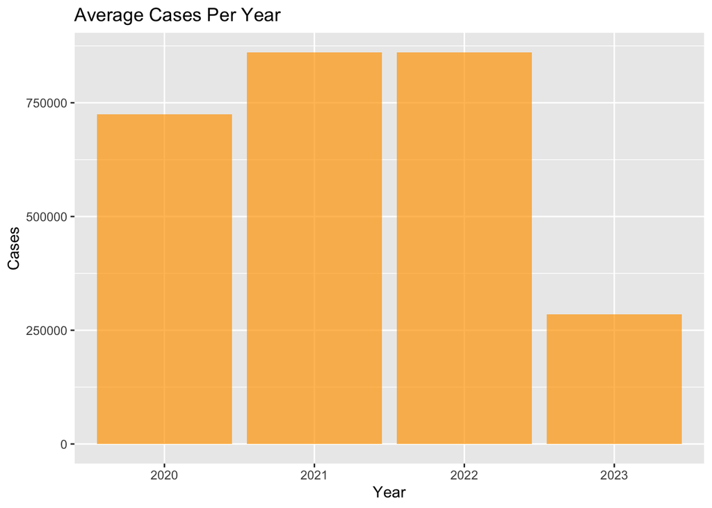

[figure not shown]

# Graphical Display of Average Deaths and Cases of COVID-19 Per Month in Each Year

[figure not shown]

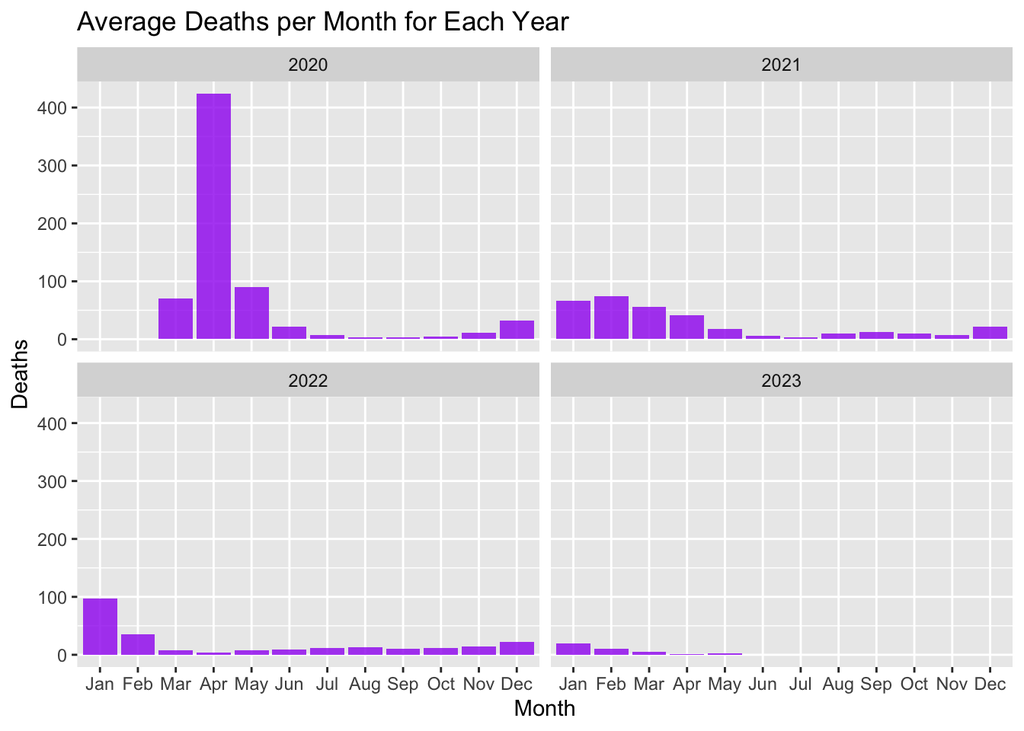

# Total Deaths by Region

Which of the five regions has the highest total death count of COVID-19?

```
##   SI_DEATH QN_DEATH MN_DEATH BK_DEATH BX_DEATH
## 1     2462    11605     5311    12107     7290
```

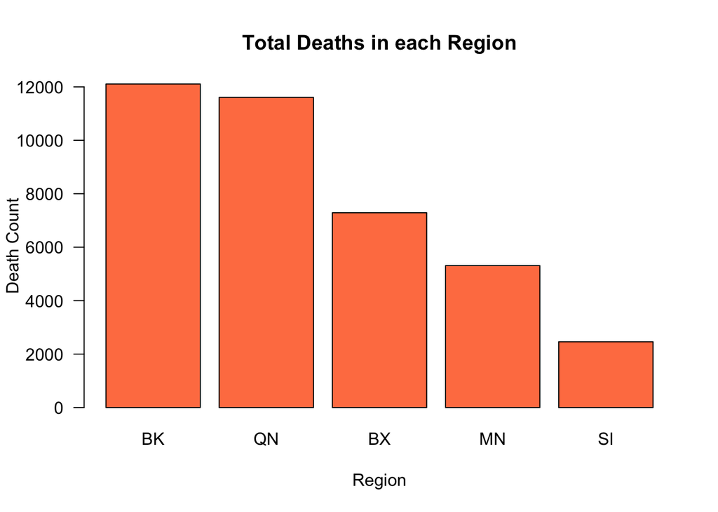

According to the data from 2020 to 2023, Brooklyn had the highest number of deaths related to COVID-19 with a total of 12,107. Queens followed with 11,605 deaths, then the Bronx with 7,290 deaths, Manhattan with 5,311 deaths, and finally Staten Island with 2,462 deaths. The order of these regions coincides with their population, which explains the differences in their death counts. In order from largest to smallest population, the regions are: Brooklyn, Queens, Bronx, Manhattan, and Staten Island.

# Which day has the most COVID-19 cases?

```
## [1] 55009
```

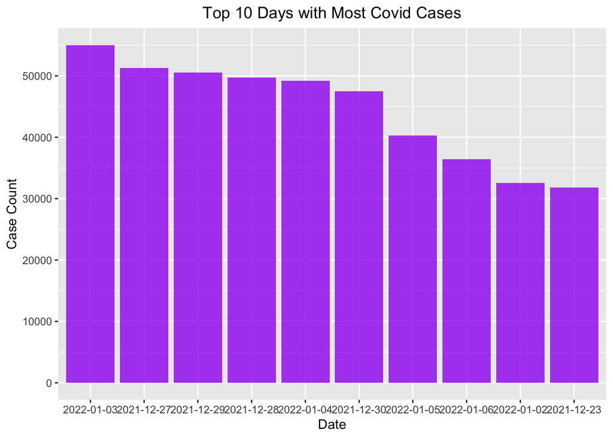

We have compiled a list of the top five days with the most COVID-19 cases. On January 3rd, 2022, there were 55,009 cases recorded, followed by 51,275 cases on December 27th, 2021. December 29th, 2021 saw 50,530 recorded cases, while December 28th, 2021 had 49,719 cases. Finally, on January 4th, 2022, 49,237 cases were recorded for NYC.

## Conclusion:

From the graphs we can see that normally there are more cases towards the beginning and end of the year, which might be cased by several factors such as national holidays or family reunion. Overall we noticed that the amount of total deaths started to decrease over time, which might be due to people being more careful such as quarantine and getting the shot. As for total cases, they started to increase, which might be due to more and more people getting tested.